# Introdução à Ciência de Dados

Bacharelado em Administração

Prof. Washington Santos da Silva

IFMG - Campus Formiga

4 de abril de 2025

## Por que investir nessas ferramentas?

**Você está construindo seu diferencial profissional**

- **O futuro é dos administradores que falam a linguagem dos dados**  
  (Pesquisa MIT: 78% das empresas buscam gestores com essas habilidades)
- **Você se torna o elo entre áreas** - perfil disputado.
- **GitHub é seu novo currículo** - projetos reais mostram competência
- **A curva de aprendizado é dura, mas temporária**  
  (em 3 meses você estará à frente de 95% (ou mais) dos administradores)
- **Não é sobre virar programador** - é sobre participar/liderar projetos digitais com propriedade

*“Hoje você pode reclamar da dificuldade… ou quando se formar reclamar que não aprendeu”*

## Nesta Aula

**Tópicos**

- Usar Outra Estratégia para Criar o Repositório do Projeto Rstudio da Disciplina no GitHub

**Diretrizes para Aulas Mais Produtivas**

🔊 **Mantenha conversas em volume baixo**

⌨️ **Código com método:**

95% dos erros são evitáveis com:

- Atenção na digitação
- Respeitar a sequência lógica de etapas
- Revisão antes de pedir ajuda

🤝 **Inteligência colaborativa:**

- Compartilhe conhecimento
- Resolva questões técnicas simples com colegas próximos
- Reserve ao professor as dúvidas conceituais complexas

💪 **Capacidade de Resolver Problemas**

Cada erro resolvido é uma evolução da sua habilidade analítica

## Nova Estratégia para Criar Repositório da Disciplina no GitHub

**Importante: Mudança de Estratégia**

- Na aula anterior, criamos projetos RStudio locais que tentamos enviar ao GitHub com `usethis::use_github()`
- Muitos tiveram problemas com tokens de autenticação, o que eu deveria ter antecipado.
- Hoje, usaremos uma abordagem mais simples: **GitHub → Local → RStudio**
- **Atenção:** Mesmo quem criou o projeto corretamente na última aula deve executar a nova estratégia.

## Nova Estratégia: GitHub → Local → RStudio

**Etapas da Estratégia**

1. Criar repositório (vazio) no GitHub
2. Clonar o repositório para seu computador
3. Criar o projeto RStudio na pasta clonada
   - Criar a estrutura de pastas e adicionar os arquivos
4. Verificar se a estrutura do projeto está correta.
5. Rastrear as pastas e arquivos do projeto com git e ignorar arquivos irrelevantes
6. Fazer um Commit
7. Enviar o Repositório Local para o GitHub

## Etapa 1: Criar Repositório no GitHub

**1. Crie um Repositório no GitHub**

- Acesse sua conta no GitHub: github.com
- Selecione “**Create repository**”
- No campo abaixo de **Repository name**, digite o nome do repositório, ex: “**seunome_icd2025_projeto**”
  - Caso tenha criado um projeto Rstudio na última aula, utilize um nome diferente do projeto que você criou.
  - **NÃO USE** acentos, espaços vazios ou caracteres especiais 😡
- Agora, apenas clique em “**Create repository**”, no canto inferior esquerdo da página.

## Etapa 1: Repositório Vazio Criado

[figure not shown]

## Etapa 2: Clonar Repositório para seu Computador

**Clonando o Repositório (Windows)**

1. Na página do repositório vazio que você acaba de criar no GitHub
2. Copie o endereço **https** exibido
3. Abra o Windows Explorer e entre na pasta onde você irá guardar a pasta do repositório que vamos clonar
   - Computadores do Laboratório: pasta Downloads (recomendada)
   - Notebook Próprio: alguns criaram a pasta github na última aula, se sim, entre nesta pasta.
4. Clique com o botão direito do mouse em um espaço vazio desta pasta e selecione “**Git Bash Here**” (Caso necessário, clique em Mais opções)
5. No terminal Git Bash que abrir, digite `git clone`, espaço, e cole o endereço do repositório que você criou clicando no botão direito do mouse e em *Paste*:

```bash
git clone https://github.com/mariasilva/seunome_icd2025_projeto.git
```

## Etapa 2: Clonar Repositório para seu Computador

**Clonando o Repositório (macOS/Linux)**

1. Abra o terminal
2. Navegue até a pasta onde deseja guardar o projeto usando o comando `cd`. Se foi em Downloads, utilize o comando:

```bash
cd Downloads/
```

3. Digite `git clone`, espaço, e cole o endereço do repositório do que você em seguida:

```bash
git clone https://github.com/mariasilva/seunome_icd2025_projeto.git
```

## Etapa 3: Criar Projeto RStudio na Pasta Clonada

**Criando um Projeto RStudio**

1. Abra o RStudio
2. Clique em **Project → New Project**
3. Selecione **Existing Directory**
4. Clique em **Browse** e navegue até a pasta “*seunome_icd2025_projeto*” que você acabou de clonar
5. Apenas clique na pasta, em seguida, clique em **Open**
6. Clique em **Create Project**

## Etapa 3: Criar Projeto RStudio na Pasta Clonada

**Se você CRIOU o projeto **corretamente** na última aula**

1. Entre na pasta do projeto que você criou na última aula, por ex. seunome_icd2025.
2. Copie a pasta **dados** e cole dentro da pasta do repositório clonado (*seunome_icd2025_projeto*)
3. Copie a pasta **relatorios** e cole dentro da pasta do repositório clonado (*seunome_icd2025_projeto*)
4. Copie o arquivo **README.md** e cole dentro da pasta do repositório clonado (*seunome_icd2025_projeto*)
5. **NÃO COPIE** o arquivo *seunome_icd2025.Rproj* do projeto criado na última aula.

## Etapa 3: Criar Projeto RStudio na Pasta Clonada

**Se você **NÃO CRIOU** ou criou o projeto com **FALHAS** na última aula**

No RStudio, na guia **Files** (canto inferior direito):

1. Clique em **New Folder** e crie a pasta “dados”
2. Dentro da pasta “dados”, crie as subpastas “brutos” e “limpos”
3. Volte à pasta principal, clique em “New Folder” e crie a pasta “relatorios”
4. Dentro da pasta “relatorios”, crie as subpastas “01-relatorio”, “02-relatorio” e “03-relatorio”
5. Acesse a página Cronograma do site da disciplina e baixe o arquivo `productionlog_sample.csv`
6. Salve o arquivo `productionlog_sample.csv` dentro da pasta “dados/brutos”
7. Baixe o arquivo `01-relatorio-html.zip` do site da disciplina
8. Descompacte o arquivo baixado e copie/recorte o arquivo `01-relatorio-html.qmd`
9. Salve-o dentro da pasta “relatorios/01-relatorio”
10. Crie o arquivo README.md fazendo:
    - No RStudio clique em: `File` -> `New File` -> `Markdown File`
    - Copie o template do slide 18 da Aula 3 e cole no arquivo criado
    - Salve o arquivo com o nome `README.md` na raíz do seu projeto RStudio

## Etapa 4: Verificar a Estrutura do Projeto

**Verifique a Estrutura do Projeto**

Você pode verificar a estrutura de pastas e arquivos do seu projeto usando a função `dir_tree()` do pacote fs.

Digite no console R do RStudio:

```r
fs::dir_tree()
```

- O pacote fs deve estar instalado para que o comando funcione.

## Etapa 4: Verificar a Estrutura do Projeto

**Verifique a Estrutura do Projeto**

Você deve a ver a seguinte estrutura de pastas e arquivos no console R, **não** necessariamente na ordem exibida a seguir:

```
seunome_icd2025_projeto/
├── dados/
│   ├── brutos/
│   │   └── productionlog_sample.csv
│   └── limpos/
├── relatorios/
│   ├── 01-relatorio/
│   │   └── 01-relatorio-html.qmd
│   ├── 02-relatorio/
│   └── 03-relatorio/
├── seunome_icd2025_projeto.Rproj
└── README.md
```

## Etapa 5: Rastrear Pastas/Arquivos com Git

**Definindo arquivos não precisamos rastrear**

- Clique no arquivo .gitignore do seu projeto
- Apague o conteúdo aque aparece
- Copie o conteúdo do próximo slide
- Cole no seu arquivo .gitignore
- Salve a alteração.

## Copie/Cole no arquivo .gitignore do seu projeto

```markdown
# Arquivos de sistema do Windows
Thumbs.db
Desktop.ini

# Arquivos de sistema do MacOS
.DS_Store

# Arquivos do RStudio
.Rproj.user/
.Rhistory
.RData
.Ruserdata

# Arquivos temporários R
*_cache/
/cache/

# Arquivos de saída
*.pdf
*.docx

# Arquivos temporários
*~
.~lock.*
*.tmp
*.bak
```

## Etapa 5: Para Rastrear Pastas/Arquivos com Git

**Usaremos 4 comandos do Git em sequência**

1. `git status` - verifica o que mudou no projeto
2. `gidd add` - adiciona o que você quer rastrear
3. `git commit - "mensagem"` - salva as mudanças localmente com uma descrição
4. `git push origin main` - envia para o GitHub (nuvem)

## Etapa 5: git add

No terminal do RStudio, digite:

```bash
git status
```

Você verá o resultado abaixo no terminal:

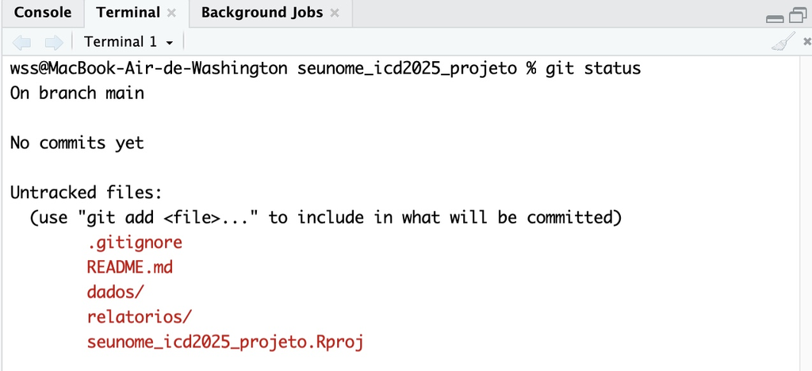

## Etapa 5: git add

- Agora, vamos adicionar as pastas/arquivos que queremos rastrear.
- Copie e Cole (usando o botão direito do mouse), cada um dos seguintes comandos no terminal:

```bash
git add .gitignore
```

```bash
git add README.md
```

```bash
git add dados/
```

```bash
git add relatorios/
```

```bash
git add seunome_icd2025_projeto.Rproj
```

## Etapa 5: Verificando as Pastas/Arquivos Adicionados

Para checar se as pastas e arquivos foram adicionados, digite no terminal:

```bash
git status
```

Você verá o resultado abaixo no terminal:

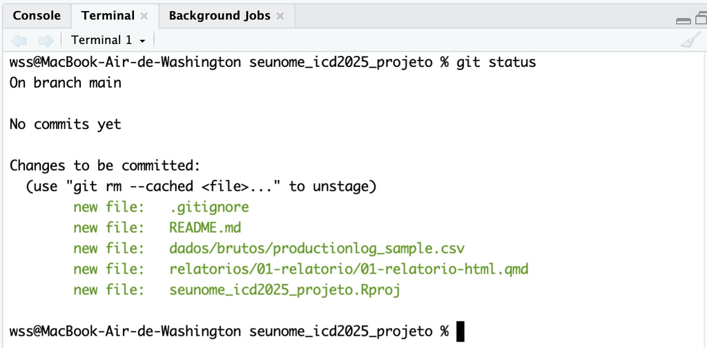

## Etapa 6: Fazer um commit

Para fazer um commit, copie/cole ou digite no console:

```bash
git commit -m "projeto iniciado"
```

Você verá o resultado abaixo no terminal:

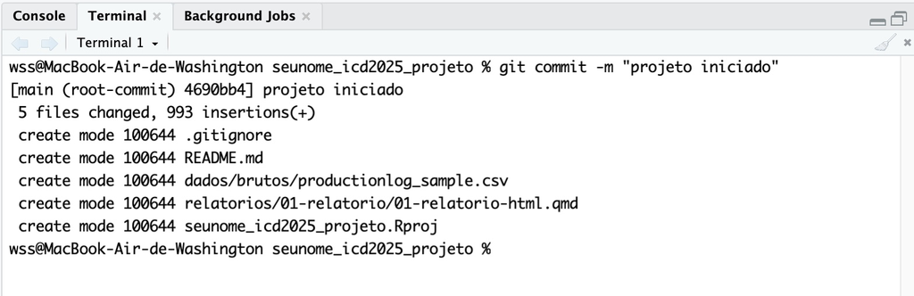

## Etapa 7: Sincronizar o Repositório Local com GitHub

Para enviar o repositório local para o GitHub digite no terminal:

```bash
git push origin main
```

Você verá o resultado abaixo no terminal:

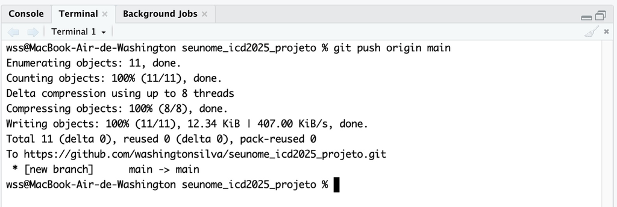

## Etapa 7: Sincronizar o Repositório Local com GitHub

**Ao fazer git push origin main**

- Seu navegador deve abrir na página de login do GitHub
- Faça o login
- Em seguida, será exibida uma página para você autorizar, clique no botão para **Autorizar**.
- Em seguida, você pode ver uma página em branco ou uma página exibindo uma mensagem para recarregar a página, isso é normal.
- Vá para a página do repositório que você criou no GitHub e atualize a página (F5).

## Repositório Criado no GitHub 😅

[figure not shown]

## Missão Cumprida! 🎯✨

**Você deu um salto profissional hoje!**

📈 **Isso não é só para a disciplina:**

- Seu perfil GitHub já é um ativo de carreira
- Parabéns! Você superou uma barreira que poucos enfrentam
- Essa estrutura vai escalar seus próximos projetos

✅ **Domínio técnico:**

- Projeto RStudio estruturado
- Controle de versão com Git local
- Portfólio público no GitHub

🌟 **Você agora está no seleto grupo de administradores** capazes de:

- Colaborar em projetos analíticos
- Documentar análises de dados que fundamentam decisões
- Mostrar trabalho replicável